# CoRps December 7, 2020

Welcome to today’s coRps session. I’ll be walking through the `glitr` package to show you some of the key features. The glitr package adorns your plots in a standardized SI style. Recent changes have been made to incorporate our new [SIEI color palette](https://github.com/USAID-OHA-SI/pretty_in_grey40K/wiki/SIEI-Data-Viz-Cheat-Sheet) that will be introduced in our SIEI style guide cheat sheet.

Let’s start by installing and loading `glitr` along with `scales`. The `scales` package has a wonderful helper function `show_col()` that quickly previews colors and color palettes.

```r
# Install the latest version from Github
  devtools::install_github("USAID-OHA-SI/glitr")
  devtools::install_github("r-lib/scales")

# Load
  library(glitr)
  library(scales)
  library(tidyverse)

# Preview all the functions/objects bundled in the package
  ls('package:glitr')
```

The package is basically divided into five parts. We’ll cover parts 1 and 2 directly.  
1) si_colors - built in colors that you can call directly  
2) si_helpers - helper functions for using SIEI color palettes in ggplots  
3) si_save - quickly save plots for SIEI Google Presentation dimensions  
4) si_style - clean, SI approved style  
5) si_themes - clean, SI approved style alternatives

```r
  dir("/Users/tim/Documents/Github/glitr/R")
```

```
 [1] "data.R"          "glitr-package.R" "globals.R"       "plot_setup.r"    "si_colors.R"
 [6] "si_helpers.R"    "si_save.R"       "si_style.R"      "si_themes.R"     "utils-pipe.R"
[11] "utils.R"
```

```r
  denim
```

```
[1] "#2057a7"
```

```r
  old_rose
```

```
[1] "#c43d4d"
```

```r
  moody_blue
```

```
[1] "#8980cb"
```

```r
  burnt_sienna
```

```
[1] "#e07653"
```

```r
  scooter
```

```
[1] "#1e87a5"
```

```r
  golden_sand
```

```
[1] "#f2bc40"
```

```r
  genoa
```

```
[1] "#287c6f"
```

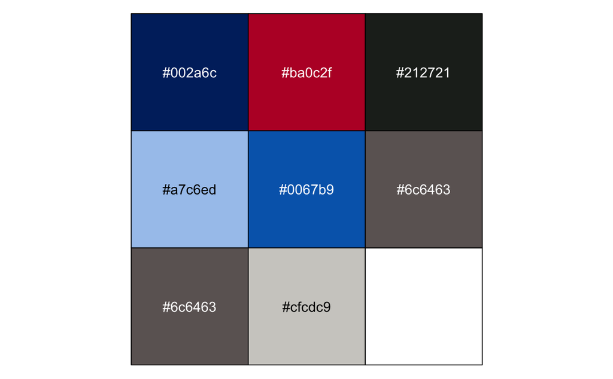

This is fine and all, but it wouldn’t it be easier if you could pass a name of [color palette](https://github.com/USAID-OHA-SI/pretty_in_grey40K/wiki/SIEI-Recommended-Colors)? The `si_rampr()` function allows you to do this.

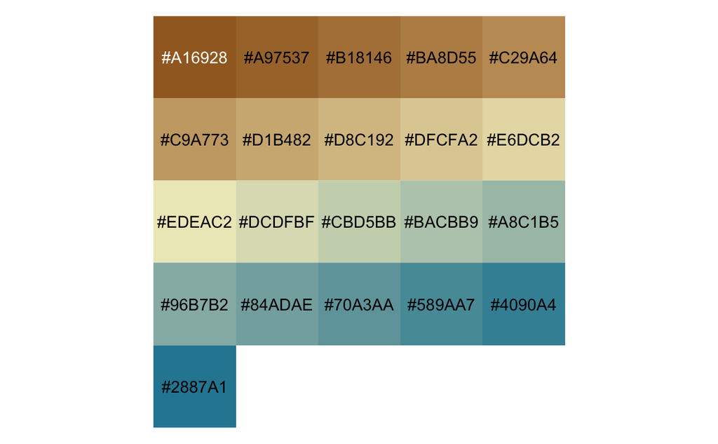

The final thing with the glitr package I’d like to cover is the scale_fill_si and scale_color_si options. If you are a frequent user of ggplot2, you are probably familiar `with scale_color_*()` / `scale_fill_*()` options. What these allow you to do is to pass colors to the aes() arguments `color` or `fill`.

To learn more: help(scale_color_si)

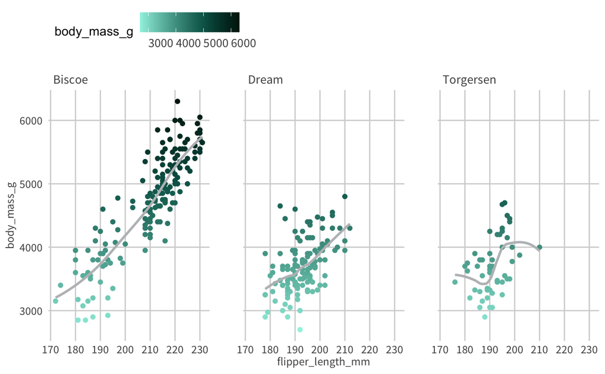

Also works with scale_fill_()* options. help(scale_fill_si)

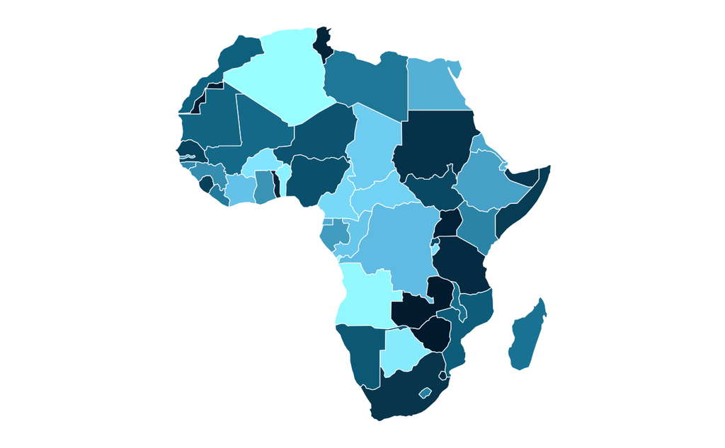